# Insurance Cross Selling (Kaggle)

Ellis Hodgdon

2024-08-08

### Introduction, setup, loading necessary libraries, and initialize variables

### Problem Definition

As a result of the acquisition of a smaller company by this company, management has decided to investigate cross-selling of their insurnce products and rewriting the business plan as necessary. To accomplish this, a data analysis is ordered to determine if cross-selling would be beneficial to the combined companies. The goal of this analysis is to predict which customers respond positively to an automobile insurance offer. A dataset has been developed that contains information about cross-selling in the insurance industry.

### Input the training dataset and data prep

Kaggle provides two datasets – training and test – but the test dataset is only used to judge the developed algorithm. It is missing the *Response* column.We will do some work on the entire training dataset and then split it into smaller datasets that we can reasonably handle.

### Description of dataset columns

Column Names in Dataset

|  | Name | Description | Class |
| --- | --- | --- | --- |
| Identification | id | id | integer |
| Gender | Gender | Gender | character |
| Age (in years) | Age | Age | integer |
| Driver’s License Nbr | Driving_License | Driving_License | integer |
| Region Code | Region_Code | Region_Code | numeric |
| Previously Insured | Previously_Insured | Previously_Insured | integer |
| Insured Vehicles Age | Vehicle_Age | Vehicle’s_age | character |
| Vehicle Damage | Vehicle_Damage | Vehicle_damage | character |
| Annual Premium | Annual_Premium | Annual Premium | numeric |
| Policy Sales Channel | Policy_Sales_Channel | Policy_Sales_Channel | numeric |
| Vintage | Vintage | Vintage | integer |
| Response | Response | Success | integer |

The column *Result* as integer (0 or 1) indicates whether a resale was successful with this customer.

### Data Preparation

Data preparation and cleaning are done by a function so that it can be reused for different test and training data sets, if necessary.

```
* The function provides the following operations
    + removal of any NAs
    + removal of any rows that contain blanks
    + checks near zero variance and removes any columns that have a near zero variance
    + converts the Gender column to numeric 1 or 0
    + converts the Vehicle_Damage column to numeric
    + converts the vehicle_Age column to a numerical value of the unique values in the column
```

```
## [1] "*** 4     Driving_License"
## [1] "*** 9     Annual_Premium"
```

This shows that Driving_License and Annual Premium are not going to be a good predictor so we should remove them from both the training and the testing datasets.

## Preprocessing

One might suspect that there would be no positive responses when there was no previous insurance applied. To determine if this is true we look at the number of positive responses when the column *Previously_Insured* is 0.

```
## [1] 1411659
```

This shows that our suspicion is not valid and we need to consider *Previously_insured* as a feature.

We now consider the *Response* column. What percentage of the reponses are positive, that is, how many cross-selling attempts were successful. We then ask the question if there are any vehicles that are not insured that have a positive response.

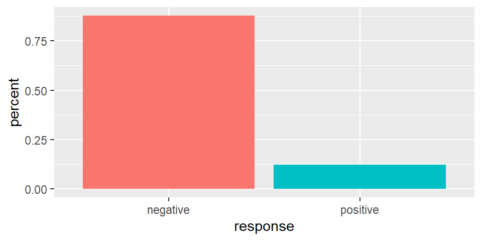

The training dataset contains over 11 million rows while the test dataset contains over 7 million rows. We will be developing this analysis on a small laptop and want to keep the the run time to be somewhat reasonable, so we will build subsets that will contain $50000.0$ and 5000 records for the training and testing datasets respectively. There will be a total of 10 testing datasets sampled from the entire training set. When training and evaluating of the various models, the same datasets will be used.

We use the k-NN method of training which has a parameter of k. We examine the accuracy of the training for various values of k. We initially try a k in the set of 3, 5, 7, 9, 11

Now consider the test sets that we carved from the original data set. How do they match with the algorithm (function *predict*)? Here are the accuracy results for the k-NN model:

Summary of k-NN testing

| Accuracy | Sensitivity | Specificity | MinMax |
| --- | --- | --- | --- |
| 0.8786 | 0.9955 | 0.0051 |  |
| 0.8772 | 0.9961 | 0.0017 |  |
| 0.8726 | 0.9945 | 0.0033 |  |
| 0.8750 | 0.9950 | 0.0033 |  |
| 0.8754 | 0.9952 | 0.0033 |  |
| 0.8720 | 0.9947 | 0.0048 |  |
| 0.8688 | 0.9954 | 0.0063 | Minimum |
| 0.8802 | 0.9980 | 0.0034 | Maximum |
| 0.8794 | 0.9966 | 0.0017 |  |
| 0.8710 | 0.9954 | 0.0016 |  |

The accuracy average for these 10 tests is 0.87502 .

This algorithm ws based on the k-NN (nearest neighbor). Other models should be tested for comparisons. The first alternative to attempt is random forest, which is a compute-intensive model. There are several parameters that can be tuned to adjust the model and we will need to build a multitude of trees. As a result of this, we will only use a five-fold cross validation. The results of the 10 test cases are as follows:

Summary of randomforest testing

| Accuracy | Sensitivity | Specificity | MinMax |
| --- | --- | --- | --- |
| 0.8820 | 1 | 0 |  |
| 0.8804 | 1 | 0 |  |
| 0.8770 | 1 | 0 |  |
| 0.8790 | 1 | 0 |  |
| 0.8792 | 1 | 0 |  |
| 0.8760 | 1 | 0 |  |
| 0.8720 | 1 | 0 | Minimum |
| 0.8816 | 1 | 0 |  |
| 0.8822 | 1 | 0 | Maximum |
| 0.8748 | 1 | 0 |  |

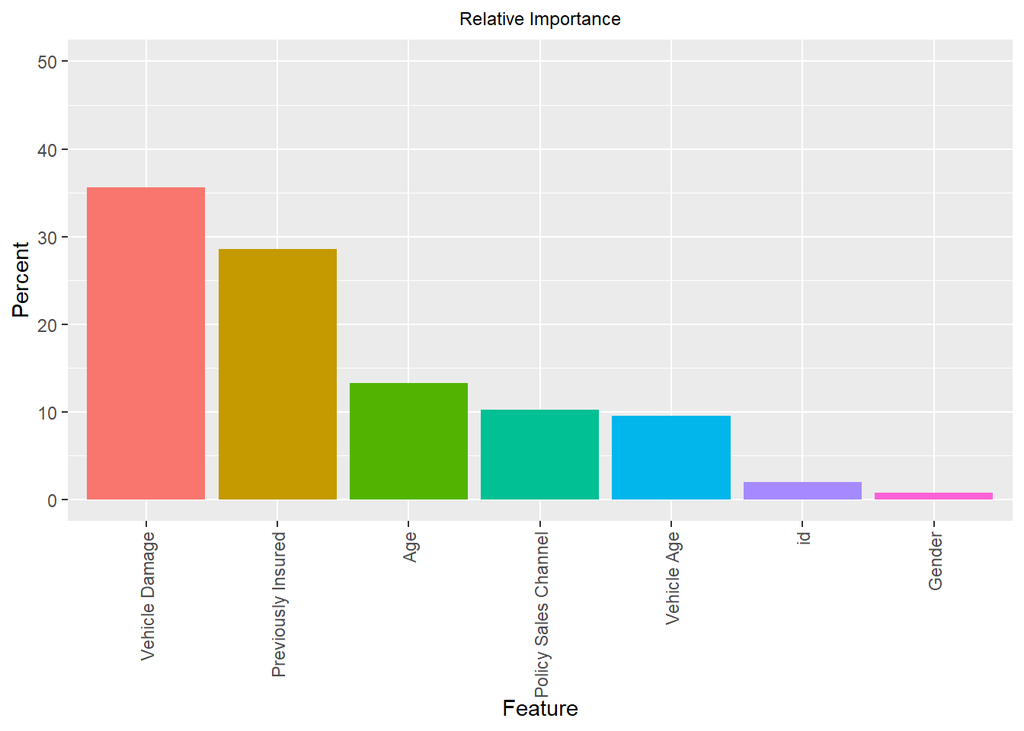

### Other models (taking defaults)

We’ve used two of the over 21,000 models that are available to determine from CRAN to determine a best fit for our data. The first model that was investigated was *glm* or General Linear Model, which is a generalization of ordinary linear regression but accommodates distributions other than normal to include poisson, gaussian, binomial, multinominal, quasi, quasibinomial and gamma. Four of the families (binomial, gaussian, quasi and quasibinomial) produced the same accuracy result of 0.5928.

### Conclusion

A sumary of the accuracy results for the models the were tested is:

| Model | Accuracy | Sensitivity | Specificity |
| --- | --- | --- | --- |
| rf | 0.8822 | 1.0000 | 0.0000 |
| ensemble | 0.8822 | 1.0000 | 0.0000 |
| k-NN | 0.8802 | 0.9980 | 0.0034 |
| k-NN ( k= 7 ) | 0.8710 | 0.9954 | 0.0016 |
| naive Bayes | 0.7152 | 0.6908 | 0.8875 |
| glm (binomial) | 0.5928 | 0.8258 | 0.0007 |
| glm (gaussian) | 0.5928 | 0.8258 | 0.0007 |
| glm (quasi) | 0.5928 | 0.8258 | 0.0007 |
| glm (quasibinomial) | 0.5928 | 0.8258 | 0.0007 |

Comparing the average for the different models, we determine thayt the random forest model gives the best accurcy.

That’s all folks!